# What Can Money Buy You in the NBA?

[figure not shown]

## Introduction

Today, the National Basketball Association is one of the most well-known professional sports leagues in the world, and is getting more and more popular every year. Recently, there has been a drastic increase in the amount of money that players are making in the league. A common question that is being asked is if it is really worth it for NBA teams to spend exorbitant amounts of money, paying high sums due to the luxury tax, and mortgaging their entire future on one shot to win a title. In this analysis, we take a look at what exactly money can buy you in the NBA, and answer whether or not throwing money at highly skilled players can lead a team to a Championship reliably.

## Data Collection

```python
import pandas as pd
import numpy as np
import matplotlib.pyplot as plt
import seaborn as sns
import statsmodels.api as sm
import statsmodels.formula.api as smf
#import matplotlib.axes as ax

#Data Can Be Found at https://data.world/jgrosz99/nba-player-data-1978-2016/workspace/file?filename=NBA+Season+Data.csv
#Salary data can be found at https://data.world/nolanoreilly495/nba-data-with-salaries-1996-2017/workspace/file?filename=NBA+Data+With+Salaries.xlsx
#Note -> 2017 means 2016 to 2017 season in player_data

player_data = pd.read_excel("NBA Data with Salaries.xlsx")
#lebron = player_data.loc[player_data['Tm'] == 'WAS' player_data['Year'] == 2017]
#mj = data.loc[data['Player'] == 'Michael Jordan']
#lebron
print(player_data['Tm'].unique())
player_data
```

```
['ATL' 'BOS' 'BRK' 'CHI' 'CHO' 'CLE' 'DAL' 'DEN' 'DET' 'GSW' 'HOU' 'IND'
 'LAC' 'LAL' 'MEM' 'MIA' 'MIL' 'MIN' 'NOP' 'NYK' 'OKC' 'ORL' 'PHI' 'PHO'
 'POR' 'SAC' 'SAS' 'TOR' 'TOT' 'UTA' 'WAS']
```

|  | Player | Year | Tm | Salary | Pos | Age | G | GS | PER | TS% | ... | FTA/G | ORB/G | DRB/G | TRB/G | AST/G | STL/G | BLK/G | TOV/G | PF/G | PTS/G |
| --- | --- | --- | --- | --- | --- | --- | --- | --- | --- | --- | --- | --- | --- | --- | --- | --- | --- | --- | --- | --- | --- |
| 0 | Dwight Howard | 2017 | ATL | 23180275 | C | 31 | 74 | 74 | 20.8 | 0.627 | ... | 5.729730 | 4.000000 | 8.702703 | 12.702703 | 1.405405 | 0.864865 | 1.243243 | 2.297297 | 2.743243 | 13.540541 |
| 1 | Paul Millsap | 2017 | ATL | 20072033 | PF | 31 | 69 | 67 | 17.8 | 0.542 | ... | 5.869565 | 1.608696 | 6.115942 | 7.724638 | 3.652174 | 1.304348 | 0.898551 | 2.289855 | 2.695652 | 18.057971 |
| 2 | Kent Bazemore | 2017 | ATL | 15730338 | SF | 27 | 73 | 64 | 11.5 | 0.504 | ... | 2.301370 | 0.616438 | 2.547945 | 3.164384 | 2.424658 | 1.246575 | 0.712329 | 1.712329 | 2.260274 | 10.972603 |
| 3 | Ersan Ilyasova | 2017 | ATL | 8400000 | PF | 29 | 26 | 12 | 13.5 | 0.530 | ... | 2.500000 | 1.615385 | 4.192308 | 5.807692 | 1.653846 | 0.846154 | 0.307692 | 1.307692 | 2.807692 | 10.384615 |
| 4 | Mike Dunleavy | 2017 | ATL | 4837500 | SF | 36 | 30 | 0 | 11.9 | 0.597 | ... | 0.866667 | 0.433333 | 1.833333 | 2.266667 | 1.000000 | 0.300000 | 0.166667 | 0.466667 | 1.166667 | 5.633333 |
| ... | ... | ... | ... | ... | ... | ... | ... | ... | ... | ... | ... | ... | ... | ... | ... | ... | ... | ... | ... | ... | ... |
| 12372 | Jeff Webster | 1996 | WAS | 0 | SF | 24 | 11 | 0 | 7.0 | 0.391 | ... | 0.000000 | 0.181818 | 0.454545 | 0.636364 | 0.272727 | 0.363636 | 0.000000 | 0.272727 | 0.636364 | 1.636364 |
| 12373 | Kevin Pritchard | 1996 | WAS | 0 | PG | 28 | 2 | 0 | 25.6 | 0.810 | ... | 1.500000 | 0.000000 | 1.000000 | 1.000000 | 3.500000 | 1.000000 | 0.000000 | 0.000000 | 1.500000 | 3.500000 |
| 12374 | Ledell Eackles | 1996 | WAS | 0 | SG | 29 | 55 | 26 | 12.5 | 0.553 | ... | 2.145455 | 0.800000 | 1.890909 | 2.690909 | 1.563636 | 0.509091 | 0.054545 | 1.036364 | 1.527273 | 8.618182 |
| 12375 | Michael Curry | 1996 | WAS | 0 | SF | 27 | 5 | 0 | 8.2 | 0.425 | ... | 0.800000 | 0.400000 | 0.600000 | 1.000000 | 0.200000 | 0.200000 | 0.000000 | 0.200000 | 0.600000 | 2.000000 |
| 12376 | Mike Peplowski | 1996 | WAS | 0 | C | 25 | 2 | 0 | -12.5 | NaN | ... | 0.000000 | 0.000000 | 0.000000 | 0.000000 | 0.000000 | 0.000000 | 0.000000 | 0.000000 | 2.000000 | 0.000000 |

12377 rows × 51 columns

In the above dataset, data is contained for all NBA players from the 1996 season to the 2017 season. Some columns of data that could be important to our analysis are

- Year: The year in which all statistics were recorded.
- Tm: The team which the player played for.
- Salary: The amount the player made, in dollars, for that particular year.
- Pos: The position that the player was listed as filling in the roster.
- PER: The player's Player Efficiency Rating. This metric is used to determine how effective and valuable a player is while on court.
- WS: The amount of win shares that the player averaged throughout the season. This metric is used to determine a player's effect on winning.

There are many more columns in this dataset, with valuable information such as a player's true shooting percentage, turnovers per game, points per game, and more. This information would be very valuable if we were studying a player's effectiveness on the floor or something similar, however for the purpose of this experiment, this data is not necessary. This will be addressed once the Data is cleaned in the next step.

## Data Cleaning and Wrangling

```python
#Creating team data dataset to compare teams, dataset created by summing up all stats for each team based on year.
team_data = player_data.groupby(['Tm', 'Year'], as_index = False).sum()
team_data

#This dataset does not contain win-loss ratio, so this must be pulled from another dataset
#Importing the new dataset
team_win_data = pd.read_excel('Historical NBA Performance.xlsx')
team_win_data

#There appears to be some missing data in the dataset. Here, we drop all rows where the player's salary is zero
player_data = player_data[player_data['Salary'] != 0]
player_data.reset_index(inplace=True)

#Switching the year format in the new dataset to match that of team_data
i = 0
for row in team_win_data.iterrows():
    year = row[1][0]
    if type(year) == str:
        year = year[:4]
        year = int(year)
    else:
        year = year.year

    team_win_data.loc[i, "Year"] = year + 1

    i = i + 1

#Dropping all data before the 1996 season, since team_data starts there
team_win_data = team_win_data[team_win_data['Year'] >= 1996]

#Creating new columns in team_data for record and winnning percentage
team_data['Record'] = "Na"
team_data['Win_Percent'] = 0

#Dictionary to convert between how the teams are listed in different databases
team_dict = {
    "Bullets" : "WAS",
    "Wizards" : "WAS",
    "Celtics" : "BOS",
    "Hawks" : "ATL",
    "Nets": "BRK",
    "Hornets": "CHO",
    "Bobcats": "CHO",
    "Bulls": "CHI",
    "Cavaliers": "CLE",
    "Mavericks": "DAL",
    "Nuggets": "DEN",
    "Pistons": "DET",
    "Warriors": "GSW",
    "Rockets": "HOU",
    "Pacers": "IND",
    "Clippers": "LAC",
    "Lakers": "LAL",
    "Grizzlies": "MEM",
    "Heat": "MIA",
    "Bucks": "MIL",
    "Timberwolves": "MIN",
    "Pelicans": "NOP",
    "Knicks": "NYK",
    "Thunder": "OKC",
    "Supersonics": "OKC",
    "Magic": "ORL",
    "76ers": "PHI",
    "Suns" : "PHX",
    "Trailblazers": "POR",
    "Kings": "SAC",
    "Spurs": "SAS",
    "Raptors": "TOR",
    "Jazz": "UTA"
}

#Assigning Win Ratio and Record values to each row in the dataset
for row in team_win_data.iterrows():
    year = row[1][0]
    team = row[1][1]
    record = row[1][2]
    pct = row[1][3]


    team_data.loc[(team_data['Year'] == year) & (team_data['Tm'] == team_dict.get(team)), 'Record'] = record
    team_data.loc[(team_data['Year'] == year) & (team_data['Tm'] == team_dict.get(team)), 'Win_Percent'] = pct


team_data = team_data[team_data['Salary'] != 0]
team_data
```

|  | Tm | Year | Salary | Age | G | GS | PER | TS% | 3PAr | FTr | ... | DRB/G | TRB/G | AST/G | STL/G | BLK/G | TOV/G | PF/G | PTS/G | Record | Win_Percent |
| --- | --- | --- | --- | --- | --- | --- | --- | --- | --- | --- | --- | --- | --- | --- | --- | --- | --- | --- | --- | --- | --- |
| 0 | ATL | 1996 | 18614000 | 501 | 774 | 410 | 238.8 | 9.004 | 3.179 | 5.381 | ... | 38.913435 | 60.069767 | 26.788764 | 12.620320 | 6.705104 | 23.088369 | 32.818043 | 137.662421 | 46-36 | 0.561 |
| 1 | ATL | 1997 | 25806100 | 464 | 781 | 410 | 178.4 | 7.626 | 3.847 | 5.335 | ... | 41.365704 | 60.589744 | 23.438860 | 11.229315 | 6.103466 | 19.470538 | 29.033882 | 121.778250 | 56-26 | 0.683 |
| 2 | ATL | 1998 | 26801827 | 442 | 787 | 410 | 210.2 | 7.999 | 2.560 | 6.910 | ... | 36.837552 | 53.529240 | 24.916978 | 10.686312 | 6.884374 | 18.647342 | 27.340045 | 121.014923 | 50-32 | 0.610 |
| 3 | ATL | 1999 | 37179940 | 392 | 513 | 250 | 194.0 | 6.685 | 1.760 | 9.181 | ... | 35.983506 | 51.945798 | 19.042242 | 8.109999 | 5.716097 | 17.495395 | 24.226162 | 109.177865 | 31-19 | 0.620 |
| 4 | ATL | 2000 | 40401646 | 365 | 818 | 410 | 180.1 | 6.960 | 1.890 | 4.229 | ... | 36.783189 | 53.203734 | 24.513549 | 7.578766 | 6.177094 | 18.858893 | 26.601986 | 116.966822 | 28-54 | 0.341 |
| ... | ... | ... | ... | ... | ... | ... | ... | ... | ... | ... | ... | ... | ... | ... | ... | ... | ... | ... | ... | ... | ... |
| 668 | WAS | 2013 | 44995631 | 498 | 852 | 410 | 208.1 | 8.957 | 4.273 | 4.403 | ... | 50.999040 | 67.349120 | 38.907389 | 12.495089 | 7.299884 | 24.622168 | 35.184656 | 144.413403 | 29-53 | 0.354 |
| 669 | WAS | 2014 | 51064905 | 453 | 857 | 410 | 212.2 | 8.602 | 3.858 | 4.019 | ... | 43.855659 | 60.014559 | 30.764127 | 11.429938 | 6.076063 | 19.766189 | 30.219166 | 133.477859 | 44-38 | 0.537 |
| 670 | WAS | 2015 | 61637082 | 515 | 915 | 410 | 202.7 | 9.148 | 3.935 | 5.279 | ... | 43.586095 | 57.704955 | 33.221055 | 9.723433 | 5.287476 | 20.466433 | 30.280625 | 128.593001 | 46-36 | 0.561 |
| 671 | WAS | 2016 | 65623817 | 531 | 872 | 410 | 244.7 | 9.943 | 5.822 | 4.977 | ... | 50.839678 | 66.239422 | 31.899527 | 12.375080 | 5.858758 | 20.010559 | 33.218652 | 155.868524 | 41-41 | 0.500 |
| 672 | WAS | 2017 | 100785911 | 462 | 853 | 410 | 217.0 | 8.740 | 5.417 | 5.851 | ... | 43.969687 | 57.243774 | 31.497308 | 11.716429 | 5.210064 | 18.256517 | 29.561094 | 139.850972 | 23-20 | 0.535 |

651 rows × 51 columns

In this phase, you have to clean your data and make sure that it fits your needs. The first thing that I realized is that I would want to not only compare players against each other, but also teams as a whole. To achieve this purpose, I created an offshoot dataframe from player_data called team_data, created by grouping player_data by the Yr and Team columns. I then summed up all of the stats, so that it would represent the entire team. Now, I would have access to information like the total salary that a team paid all of its players for a specific season.

After this, I also realized that there was some missing data in the player_data dataset. Some of the players were listed as having a salary of 0. I'm not sure why this data is missing, but I know that keeping this data in the dataset would likely have an effect on any analysis done, and so I made sure to remove all of this data. Unfortunately, this means that this data is not 100% accurate in terms of the total salary paid by each team, but the difference is not so large that the findings should be completely disregarded.

Next, I realized that I would probably need statstics to measure how successful a team had been during a particular season. Most commonly, this is determined by a team's win-loss record. Unfortunately, the dataset that I got all my data from didn't include this information, and so I had to find it somewhere else. To get this information, I found another dataset that contained just the team's records and winning percentages, and then combined this data with the team_data dataset.

## Exploratory Data Analysis

### Graphing the change in NBA Salaries Over Time

One thing that is important to look over before any analysis is done is to see how exactly NBA salaries have changed over the multiple decades that this dataset spans, to see if there are any trends that can be spotted. Below is a scatter plot of all of the total salaries paid by each team, grouped by year, and differentiated using different colors for each individual team. A regression line has also been added to show the general trend over the years.

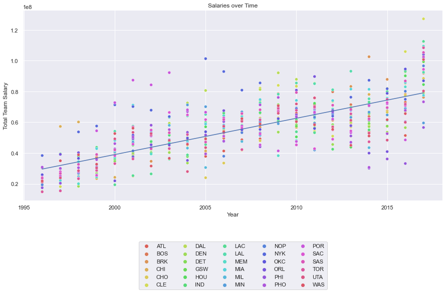

```python
#Creating a color palette to differentiate the 30 NBA teams
color_palette = sns.color_palette("hls", 30)

#Setting the size of the plot
sns.set(rc={"figure.figsize":(15, 7)})

#Creating a scatter plot of teams' salaries over time.
sns.scatterplot(x="Year", y="Salary", data=team_data, palette=color_palette, hue='Tm')
plt.legend(loc=9, bbox_to_anchor=(0.5, -0.2), ncol=5)
plt.title("Salaries over Time")
plt.xlabel("Year")
plt.ylabel("Total Team Salary")

#Adding a regression line so the trend can be determined
m, b = np.polyfit(team_data['Year'], team_data['Salary'], 1)
plt.plot(team_data['Year'], (m*team_data['Year']) + b)

plt.show()
```

From the plot above, the most obvious conclusion that we can draw is that there is a positive relationship between salary and time. As the years progress, the salaries that NBA teams are paying out are increasing. There could be a multitude of reasons for this, for example inflation, or the fact that the NBA has gotten more and more popular over the years, and thus has generated more revenue to be shared amongst the league. However, this could also indicate a change in mindset across the league that the more money you throw at acquiring top talent, the more you will win.

Another interesting aspect that can be seen is that for many of the years represented here, there are a few teams that are outspending the rest significantly. For example, during the last season recorded in this dataset (2016-2017), the Cleveland Cavaliers had the highest payroll in the league, and it wasn't close. Clearly, these teams had championship aspirations, and took the approach of acquiring the best talent at the highest prices. It will be interesting to look at these teams in particular further into the experiment to see if their strategy paid off.

### Analyzing the Distribution of Player Salaries

The next piece of exploratory data analysis that was important to look at was the distribution of player salaries, and to see what insights could be gained. To do this, two different box-plot diagrams were created. The first diagram simply shows the box plot of all players in the dataset. Next, to make sure that the singular box plot was representative of all players regardless of the position that they played, the dataset was grouped by player positions, and box plots of their salaries were made as well.

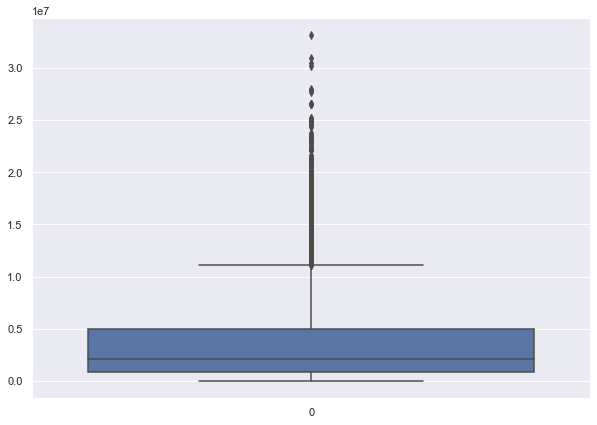

```python
#Creating boxplots of player salaries
sns.set(rc={"figure.figsize":(10, 7)})
sns.boxplot(data=player_data['Salary'])
plt.show()
```

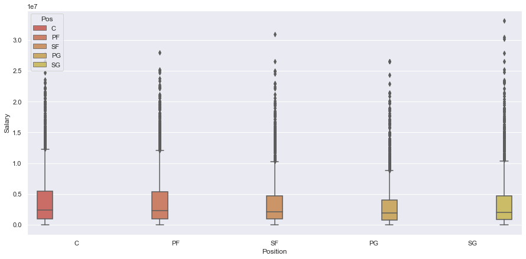

```python
#Creating boxplots of salary based on position, to see if this has any effect
sns.set(rc={"figure.figsize":(15, 7)})
sns.boxplot(x='Pos', y='Salary', data=player_data, palette=color_palette, hue='Pos')
plt.xlabel("Position")
plt.show()
```

Looking at the box plot for the data split up by position, it can be seen that each box plot is very similar to the others, with very similar means and quartiles. Based on this, it can be concluded that the position that a player plays does not have a significant effect on their salary, and so when analyzing the distribution of player salaries, all positions can be looked at together.

Looking at the distribution of player salaries, some clear patterns can be seen. It seems that the median NBA salary is in the low single-millions, around $2,000,000, with the interquartile range being within the range of $5,000,000. It can also be seen that there are some very significant outliers near the top of the box plot, which represent the superstars in the league.

These outliers clearly show that most NBA teams see value in paying a significantly above average salary to players that they believe would have a large impact on winning during the NBA season. However, only one team can win the Championship each year, so this strategy can't always work. The next question that we need to answer is whether or not higher-paid NBA players (and by implication, higher-skilled) actually have an impact on winning in the NBA.

## Can You Buy Success in the NBA?

### High-Salaried Players and their Effects on Winning

Based off of the conclusions of the previously plotted data, it is clear that NBA teams pay substantial salaries to players that they beleive will have a substantial impact on the amount that the team will win. We want to see how often this approach actually works. Luckily for us, the NBA keeps track of a statistic, called Win Shares, which can be used to see a player's true impact on winning.

Each time a team gets a win, the players on the team are assigned a win share value. Essentially, the higher a player's win share for a game that they won, the more they contributed to achieving that win. Win shares are stored in one column of the player_data dataset, and to analyze high-salaried players' effects on winning, a scatter plot of Win Shares vs. Salary was created below.

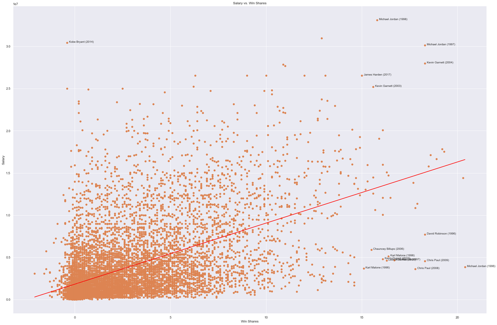

```python
#Making plot larger to accomodate large amounts of data and make labels easier to read
sns.set(rc={"figure.figsize":(30, 20)})

#Creating a plot of win shares vs. payroll for a player
sns.scatterplot(x='WS', y='Salary', data = player_data)
plt.scatter(player_data['WS'], player_data['Salary'])
plt.title("Salary vs. Win Shares")
plt.xlabel("Win Shares")
plt.ylabel("Salary")

#Plotting a regression line over the scatter plot
m, b = np.polyfit(player_data['WS'], player_data['Salary'], 1)
plt.plot(player_data['WS'], (m*player_data['WS']) + b, c='red')

#Labeling significant points on the Scatter Plot
for i in range(12377):
    if ((player_data.WS[i] < 0 or player_data.WS[i] >= 15) and player_data.Salary[i] > 25000000 ) or \
        (player_data.WS[i] > 15  and player_data.Salary[i] < 10000000):
        string = f"{player_data.Player[i]} ({player_data.Year[i]})"
        plt.text(x=player_data.WS[i] + 0.1, y = player_data.Salary[i] + 0.1, s=string, size=10)
```

From the above plot, it can be seen that there is a clear positive linear relationship between salary and win shares. The vast majority of NBA players seem to be clustered around the bottom left - lower salaries and lower win shares. However, there can also be seen to be some significant outliers. There are a few players in the top right corner. These are players who have very high salaries, but also contribute a lot to winning, such as Michael Jordan during the 1997 and 1998 season, in the middle of the Bulls' second three-peat. This, plus the positive linear relationship lend evidence to the argument that throwing money at highly-skilled players helps a team win.

However, therea are also a lot of players that are in the top left corner: high salary, but little contribution to winning, for example Kobe Bryant in the 2014 season. There are also many players in the bottom right corner, who contribute a lot to wins, but don't have high salaries, for example Kevin Durant in 2010 and LeBron James in 2006. An interesting takeaway from this subset of the data is that many of the players with high win shares and lower salaries were players that were still on their rookie contracts, and they can be found at the top right corner as years pass and their value skyrockets because of their effect on winning. From this, it can be seen that the most valuable contract in the NBA is the rookie contract.

These findings show that generally, the formula of giving higher skilled players higher salaries does lead to teams winning, but there are many times when this isn't the case. Currently, we are looking at the players' sides of things. Next, we should look at whether or not the teams that paid the most in salary historically were the teams that ended up with the best win-loss ratios.

### Regression Analysis of Payroll vs. Winning Percentages for NBA Teams

We want to analyze whether or not having a higher payroll in a season correlates with having a higher win ratio. To do this, a linear regression was used using the tools provided by the statsmodels library and the OLS regression features it contains. The regression line was also plotted for clarity. The analysis of the regression will be found below.

```
                            OLS Regression Results
==============================================================================
Dep. Variable:            Win_Percent   R-squared:                       0.034
Model:                            OLS   Adj. R-squared:                  0.032
Method:                 Least Squares   F-statistic:                     22.73
Date:                Wed, 14 Dec 2022   Prob (F-statistic):           2.31e-06
Time:                        17:10:15   Log-Likelihood:                 98.553
No. Observations:                 651   AIC:                            -193.1
Df Residuals:                     649   BIC:                            -184.1
Df Model:                           1
Covariance Type:            nonrobust
==============================================================================
                 coef    std err          t      P>|t|      [0.025      0.975]
------------------------------------------------------------------------------
Intercept      0.3422      0.024     14.247      0.000       0.295       0.389
Salary      1.974e-09   4.14e-10      4.767      0.000    1.16e-09    2.79e-09
==============================================================================
Omnibus:                       42.114   Durbin-Watson:                   0.456
Prob(Omnibus):                  0.000   Jarque-Bera (JB):               49.314
Skew:                          -0.674   Prob(JB):                     1.96e-11
Kurtosis:                       2.987   Cond. No.                     1.71e+08
==============================================================================

Notes:
[1] Standard Errors assume that the covariance matrix of the errors is correctly specified.
[2] The condition number is large, 1.71e+08. This might indicate that there are
strong multicollinearity or other numerical problems.
```

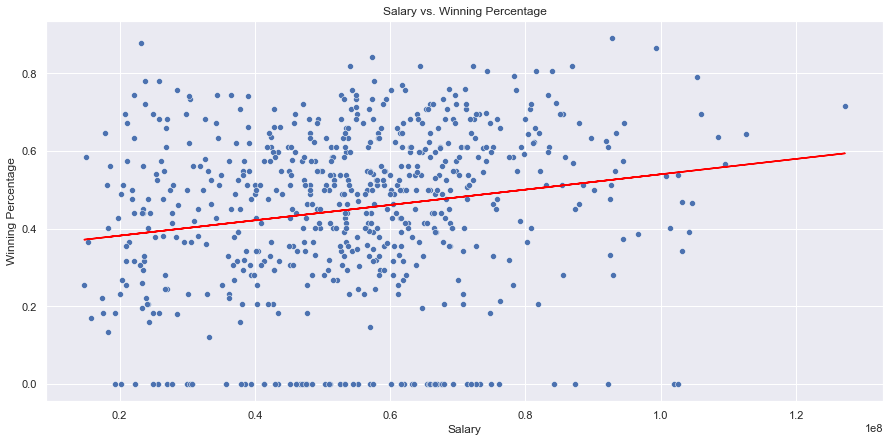

```python
#Creating scatterplot
sns.scatterplot(x='Salary', y='Win_Percent', data = team_data)
plt.title("Salary vs. Winning Percentage")
plt.xlabel("Salary")
plt.ylabel("Winning Percentage")

#Fitting Regression Line
m, b = np.polyfit(team_data['Salary'], team_data['Win_Percent'], 1)
plt.plot(team_data['Salary'], (m*team_data['Salary']) + b, c='red')

#Displaying Linear Regression Summary Statistics
model = smf.ols(formula='Win_Percent ~ Salary', data=team_data).fit()
print(model.summary())
```

From the plot above, it it seems like there is a positive linear relationship between the salary that a team is paying out, and their winning percentage. However, there is also tons of data both above and below the line, showing that this is not always the case. To see if there actually is a relationship between the two variables, a hypothesis test must be conducted.

The test will be conducted at the 5% Confidence Level, with the Null Hypothesis being that the coefficient is equal to zero. To decide whether we accept or reject the Null Hypothesis, we must look at the p-value given to us in the summary statistics. From the summary, it can be seen that the p-value is zero, which is less than our confidence level of 0.05. Because of this, we can reject the null hypothesis, confirming that there is indeed a correlation between the Salary and the Winning Percentage of an NBA team.

Now, it's clear that a higher salary does have a correlation with winning in the NBA, but ultimately, a team's win-loss record doesn't matter at the end of the day. What matters is whether or not they were able to win a championship. Next, we must analyze whether a higher salary leads to winning championships.

### Analysis of Payroll vs. Championships

To analyze whether a higher salary leads to championships, first data needed to be added to the dataset representing which teams won championships. After this, a scatterplot of salary vs. Year was plotted, very similar to the one plotted during the exploratory data analysis. However, this time the plot was differentiated by which teams won a championship and which ones didn't.

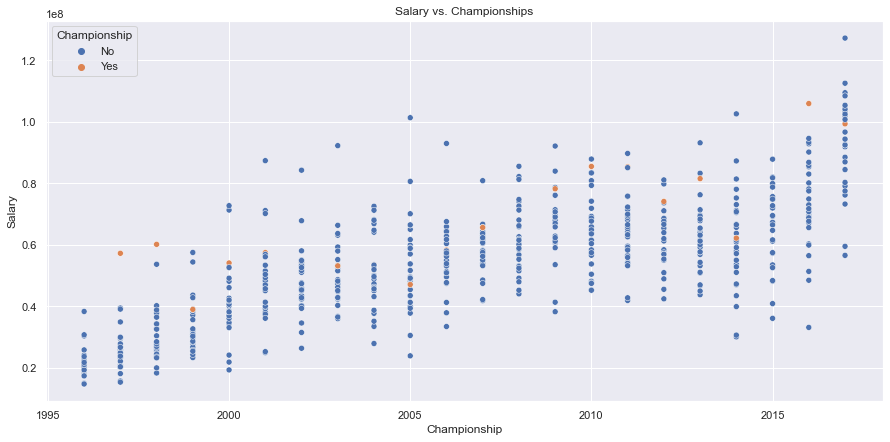

```python
#No data on championships won. Need to add it
#Added data manually since it is small enough and I couldn't find a dataset that included this information
team_data['Championship'] = "No"
team_data.loc[(team_data['Year'] == 2017) & (team_data['Tm'] == 'GSW'), 'Championship'] = "Yes"
team_data.loc[(team_data['Year'] == 2016) & (team_data['Tm'] == 'CLE'), 'Championship'] = "Yes"
team_data.loc[(team_data['Year'] == 2015) & (team_data['Tm'] == 'GSW'), 'Championship'] = "Yes"
team_data.loc[(team_data['Year'] == 2014) & (team_data['Tm'] == 'SAS'), 'Championship'] = "Yes"
team_data.loc[(team_data['Year'] == 2013) & (team_data['Tm'] == 'MIA'), 'Championship'] = "Yes"
team_data.loc[(team_data['Year'] == 2012) & (team_data['Tm'] == 'MIA'), 'Championship'] = "Yes"
team_data.loc[(team_data['Year'] == 2011) & (team_data['Tm'] == 'DAL'), 'Championship'] = "Yes"
team_data.loc[(team_data['Year'] == 2010) & (team_data['Tm'] == 'LAL'), 'Championship'] = "Yes"
team_data.loc[(team_data['Year'] == 2009) & (team_data['Tm'] == 'LAL'), 'Championship'] = "Yes"
team_data.loc[(team_data['Year'] == 2008) & (team_data['Tm'] == 'BOS'), 'Championship'] = "Yes"
team_data.loc[(team_data['Year'] == 2007) & (team_data['Tm'] == 'SAS'), 'Championship'] = "Yes"
team_data.loc[(team_data['Year'] == 2006) & (team_data['Tm'] == 'MIA'), 'Championship'] = "Yes"
team_data.loc[(team_data['Year'] == 2005) & (team_data['Tm'] == 'SAS'), 'Championship'] = "Yes"
team_data.loc[(team_data['Year'] == 2004) & (team_data['Tm'] == 'DET'), 'Championship'] = "Yes"
team_data.loc[(team_data['Year'] == 2003) & (team_data['Tm'] == 'SAS'), 'Championship'] = "Yes"
team_data.loc[(team_data['Year'] == 2002) & (team_data['Tm'] == 'LAL'), 'Championship'] = "Yes"
team_data.loc[(team_data['Year'] == 2001) & (team_data['Tm'] == 'LAL'), 'Championship'] = "Yes"
team_data.loc[(team_data['Year'] == 2000) & (team_data['Tm'] == 'LAL'), 'Championship'] = "Yes"
team_data.loc[(team_data['Year'] == 1999) & (team_data['Tm'] == 'SAS'), 'Championship'] = "Yes"
team_data.loc[(team_data['Year'] == 1998) & (team_data['Tm'] == 'CHI'), 'Championship'] = "Yes"
team_data.loc[(team_data['Year'] == 1997) & (team_data['Tm'] == 'CHI'), 'Championship'] = "Yes"
team_data.loc[(team_data['Year'] == 1996) & (team_data['Tm'] == 'CHI'), 'Championship'] = "Yes"

#Plotting scatterplot of salary vs. year, differentiated by whether or not the team won a championship
sns.scatterplot(x='Year', y='Salary', data = team_data, hue='Championship')
plt.title("Salary vs. Championships")
plt.xlabel("Championship")
plt.ylabel("Salary")
```

Looking at the plot above, it can be seen that may years, the team that won the NBA championship was at the upper end in terms of total salary payout. For example, in 2016, the Championship was won by the team that had the highest salary out of all teams. Interestingly though, there seem to be just as many instances of teams that have salaries around the average, or even lower than that that have won the championship. For example, in 2017 the Warriors won the championship while having a salary only slightly higher than the average for that year. From this data analysis, it doesn't seem like the salary that an NBA team pays out to its players each year has an effect on whether or not the team is able to win the championship. There certainly seems to be some correlation, as a team with a salary on the absolute lower end has never ended up winning the championship in this dataset, however once a certain threshold is reached, it seems like the salary no longer matters.

## Conclusion

After analyzing all of the data given available, a few conclusions can be drawn. The first question that we had was whether or not higher-paid players (and by implication higher-skilled) actually had an impact on whether or not a team was winning. Looking at the plot of player win shares vs. salary, it can be seen that there is a general trend that as a player's salary increases, so do their win shares. This shows that NBA teams are generally spending their money in the right places, and getting effective contributors to winning. However, the many outliers also gave us insights. For example, many of the players that had high contributions to winning but low salaries (like LeBron James, Kevin Durant, and Chris Paul in their early years) were on their rookie contract. This tells us that the most valuable contract in the NBA is a rookie contract, as you can get superstar level performances for a bargain price.

Our second question was to see if there was any correlation between teams that paid out the highest salaries and their win-loss records. After performing a regression analysis on the dataset, it was clear that there was a correlation between the teams paying the highest salaries and having a higher win loss ratio.

Finally, we wanted to see if money really can buy a championship. From an analysis of the data, it could be seen that often times, teams with one of the highest payrolls in the league did end up winning the championship, but it was just as often that a team with an average or below average payroll was able to win the championship. There could be many reasons for this. Higher salaries could lead to regular season success because the large number of games tends to allow things to even out in the end, and the teams with the most talent end up coming out on top. However, the post-season is much more unpredictable, and there are a much smaller amount of games that are played. The level of competition is higher, and the stakes are raised. An underdog team can get hot, and go all the way. In the end, shelling out big money for the most talented players does not guarantee a championship, although it is a viable strategy, as can be seen by examples such as the 2016 Cleveland Cavaliers.

Overall, this experiment was able to clear up many questions about the value of money in the NBA, and how far money can get a team in its quest to capture the Larry O'Brian trophy at the end of the year.